# Final_Project_Binpeng_Zhang

Binpeng Zhang

5/14/2018

## Pokemon Tutorial: How To Be The Very Best Dragon Pokemon Trainer

# Introduction:

Since Pokemon’s release in 1996, it has grown in popularity. There have been many animes, games and trading cards based on the series. The immense growth in popular and a huge fanbase allowed for Pokemon to become a competitive field. There are many people dedicated to becoming the very best pokemon trainer in the world. I have created this simple and easier to understand tutorial that will teach you to become the very best dragon type pokemon trainer, because dragons are the best. I will also teach you Data curation, parsing and management, exploratory data analysis, hypothesis testing, machine learning and how to draw insights from the data set using R. ## Data Curation, Parsing and Management First we have to load in the dataset of 721 Pokemon, including their number, name, first and second type, and basic stats: HP, Attack, Defense, Special Attack, Special Defense, and Speed from https://www.kaggle.com/abcsds/pokemon. We will also load the necessary libraries such as tidyverse and stringr that will help us later with function calls. You can get more information on the libraries by clicking the following links: -https://www.tidyverse.org/ for information on the tidyverse library -https://cran.r-project.org/web/packages/stringr/vignettes/stringr.html for information on the stringr library

```r
library(tidyverse)
library(stringr)
PokemonStats <- read.csv("/Users/bzhang/Documents/cmsc320/Project4/Pokemon.csv")
head(PokemonStats)
```

```
##   X.                  Name Type.1 Type.2 Total HP Attack Defense Sp..Atk
## 1  1             Bulbasaur  Grass Poison   318 45     49      49      65
## 2  2               Ivysaur  Grass Poison   405 60     62      63      80
## 3  3              Venusaur  Grass Poison   525 80     82      83     100
## 4  3 VenusaurMega Venusaur  Grass Poison   625 80    100     123     122
## 5  4            Charmander   Fire          309 39     52      43      60
## 6  5            Charmeleon   Fire          405 58     64      58      80
##   Sp..Def Speed Generation Legendary
## 1      65    45          1     False
## 2      80    60          1     False
## 3     100    80          1     False
## 4     120    80          1     False
## 5      50    65          1     False
## 6      65    80          1     False
```

Since we only want to be a Dragon Pokemon Trainer we will tidy the data to filter out all useless non dragon type pokemons. We will also tidy names of pokemon such as AltariaMega Altaria to just AltariaMega since repeating Altaria is just redundant.

```r
DragonStats <- PokemonStats %>%
  filter(Type.1 == "Dragon" | Type.2 == "Dragon")
# before tidying Mega
DragonStats
```

```
##     X.                      Name   Type.1   Type.2 Total  HP Attack
## 1    6 CharizardMega Charizard X     Fire   Dragon   634  78    130
## 2  147                   Dratini   Dragon            300  41     64
## 3  148                 Dragonair   Dragon            420  61     84
## 4  149                 Dragonite   Dragon   Flying   600  91    134
## 5  181     AmpharosMega Ampharos Electric   Dragon   610  90     95
## 6  230                   Kingdra    Water   Dragon   540  75     95
## 7  254     SceptileMega Sceptile    Grass   Dragon   630  70    110
## 8  329                   Vibrava   Ground   Dragon   340  50     70
## 9  330                    Flygon   Ground   Dragon   520  80    100
## 10 334                   Altaria   Dragon   Flying   490  75     70
## 11 334       AltariaMega Altaria   Dragon    Fairy   590  75    110
## 12 371                     Bagon   Dragon            300  45     75
## 13 372                   Shelgon   Dragon            420  65     95
## 14 373                 Salamence   Dragon   Flying   600  95    135
```

[output cut: 87 more lines]

```r
DragonStats$Name<- str_extract(DragonStats$Name,boundary("word"))
# after tidying all the Mega pokemons
DragonStats
```

```
##     X.            Name   Type.1   Type.2 Total  HP Attack Defense Sp..Atk
## 1    6   CharizardMega     Fire   Dragon   634  78    130     111     130
## 2  147         Dratini   Dragon            300  41     64      45      50
## 3  148       Dragonair   Dragon            420  61     84      65      70
## 4  149       Dragonite   Dragon   Flying   600  91    134      95     100
## 5  181    AmpharosMega Electric   Dragon   610  90     95     105     165
## 6  230         Kingdra    Water   Dragon   540  75     95      95      95
## 7  254    SceptileMega    Grass   Dragon   630  70    110      75     145
## 8  329         Vibrava   Ground   Dragon   340  50     70      50      50
## 9  330          Flygon   Ground   Dragon   520  80    100      80      80
## 10 334         Altaria   Dragon   Flying   490  75     70      90      70
## 11 334     AltariaMega   Dragon    Fairy   590  75    110     110     110
## 12 371           Bagon   Dragon            300  45     75      60      40
## 13 372         Shelgon   Dragon            420  65     95     100      60
## 14 373       Salamence   Dragon   Flying   600  95    135      80     110
```

[output cut: 87 more lines]

```r
# select only the fields I am interested in
DragonStats <- select(DragonStats, X. , Name, Type.1,Type.2,Total, Generation, Legendary)
DragonStats
```

```
##     X.            Name   Type.1   Type.2 Total Generation Legendary
## 1    6   CharizardMega     Fire   Dragon   634          1     False
## 2  147         Dratini   Dragon            300          1     False
## 3  148       Dragonair   Dragon            420          1     False
## 4  149       Dragonite   Dragon   Flying   600          1     False
## 5  181    AmpharosMega Electric   Dragon   610          2     False
## 6  230         Kingdra    Water   Dragon   540          2     False
## 7  254    SceptileMega    Grass   Dragon   630          3     False
## 8  329         Vibrava   Ground   Dragon   340          3     False
## 9  330          Flygon   Ground   Dragon   520          3     False
## 10 334         Altaria   Dragon   Flying   490          3     False
## 11 334     AltariaMega   Dragon    Fairy   590          3     False
## 12 371           Bagon   Dragon            300          3     False
## 13 372         Shelgon   Dragon            420          3     False
## 14 373       Salamence   Dragon   Flying   600          3     False
```

[output cut: 36 more lines]

In some competitive tournaments legendary pokemons are not allowed so I will create two data sets: One data set for Legendary Pokemons One data set for Non-Legendary Pokemons

```r
LegendaryDragons <- DragonStats %>%
  filter(Legendary == "True")

NonLegendary <- DragonStats %>%
  filter(Legendary == "False")

LegendaryDragons
```

```
##     X.            Name Type.1   Type.2 Total Generation Legendary
## 1  380          Latias Dragon  Psychic   600          3      True
## 2  380      LatiasMega Dragon  Psychic   700          3      True
## 3  381          Latios Dragon  Psychic   600          3      True
## 4  381      LatiosMega Dragon  Psychic   700          3      True
## 5  384        Rayquaza Dragon   Flying   680          3      True
## 6  384    RayquazaMega Dragon   Flying   780          3      True
## 7  483          Dialga  Steel   Dragon   680          4      True
## 8  484          Palkia  Water   Dragon   680          4      True
## 9  487 GiratinaAltered  Ghost   Dragon   680          4      True
## 10 487  GiratinaOrigin  Ghost   Dragon   680          4      True
## 11 643        Reshiram Dragon     Fire   680          5      True
## 12 644          Zekrom Dragon Electric   680          5      True
## 13 646          Kyurem Dragon      Ice   660          5      True
## 14 646     KyuremBlack Dragon      Ice   700          5      True
## 15 646     KyuremWhite Dragon      Ice   700          5      True
## 16 718       Zygarde50 Dragon   Ground   600          6      True
```

```r
NonLegendary
```

```
##     X.          Name   Type.1 Type.2 Total Generation Legendary
## 1    6 CharizardMega     Fire Dragon   634          1     False
## 2  147       Dratini   Dragon          300          1     False
## 3  148     Dragonair   Dragon          420          1     False
## 4  149     Dragonite   Dragon Flying   600          1     False
## 5  181  AmpharosMega Electric Dragon   610          2     False
## 6  230       Kingdra    Water Dragon   540          2     False
## 7  254  SceptileMega    Grass Dragon   630          3     False
## 8  329       Vibrava   Ground Dragon   340          3     False
## 9  330        Flygon   Ground Dragon   520          3     False
## 10 334       Altaria   Dragon Flying   490          3     False
## 11 334   AltariaMega   Dragon  Fairy   590          3     False
## 12 371         Bagon   Dragon          300          3     False
## 13 372       Shelgon   Dragon          420          3     False
## 14 373     Salamence   Dragon Flying   600          3     False
```

[output cut: 20 more lines]

## Exploratory Data Analysis

Now that we have tidied the data to what we are interested in we can perform some exploratory data analysis on it. We can do things like finding the strongest legendary dragon pokemon or the strongest non legendary pokemon. We define the strongest by the pokemon with the highest total stat. We can find the strongest legendary dragon pokemon by arranging the LegendaryDragons data frame in descending order by total stats using the arrange function and taking the first entity.

```r
StrongestLegend <- LegendaryDragons %>%
  arrange(desc(Total)) %>%
  head(1)
StrongestLegend
```

```
##    X.         Name Type.1 Type.2 Total Generation Legendary
## 1 384 RayquazaMega Dragon Flying   780          3      True
```

We can find the strongest non legendary dragon pokemon by arranging the NonLegendary data frame in descending order by total stats using the arrange function and taking the first entity.

```r
StrongestNonLegend <- NonLegendary %>%
  arrange(desc(Total)) %>%
  head(1)
StrongestNonLegend
```

```
##    X.          Name Type.1 Type.2 Total Generation Legendary
## 1 373 SalamenceMega Dragon Flying   700          3     False
```

As we can see from the two data frame, the strongest legendary dragon pokemon RayquazaMegais stronger than the strongest non legendary dragon pokemon SalamenceMega by 80 total stat points. This may suggest that legendary dragon pokemons are significantly stronger than non legendary dragon pokemons. We will now create some data frames that will summarize these two dataset that will help us get a better analysis of what’s going on.

```r
NonLegendarySummary <- DragonStats %>%
  group_by(Legendary) %>%
  summarize(min_stat=min(Total), mean_stat=mean(Total), max_stat=max(Total) , sd_stat = sd(Total))
NonLegendarySummary
```

```
## # A tibble: 2 x 5
##   Legendary min_stat mean_stat max_stat sd_stat
##   <fct>        <dbl>     <dbl>    <dbl>   <dbl>
## 1 False          245       479      700   130
## 2 True           600       675      780    45.3
```

From the above table it seems that the average legendary dragon pokemon is much stronger than the average non legendary dragon pokemon. Now we want to visualize the data so we can have a pictorial representation of what’s going on so it is more intuitive.

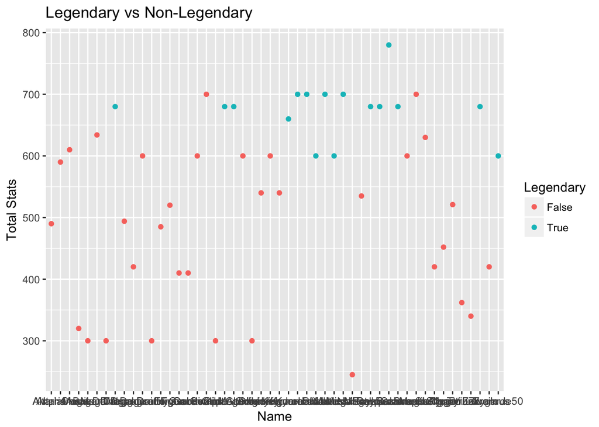

```r
nonvslegend <- DragonStats %>%
  ggplot(mapping = aes(x=Name,y=Total)) +
  geom_point(aes(color = Legendary)) +
  ggtitle("Legendary vs Non-Legendary") +
  ylab("Total Stats") + xlab("Name")
nonvslegend
```

From the scatter plot above it seems pretty obvious that legendary dragon pokemons are stronger in general, however just to be even more intuitive we are going to create a box plot to have a direct comparison.

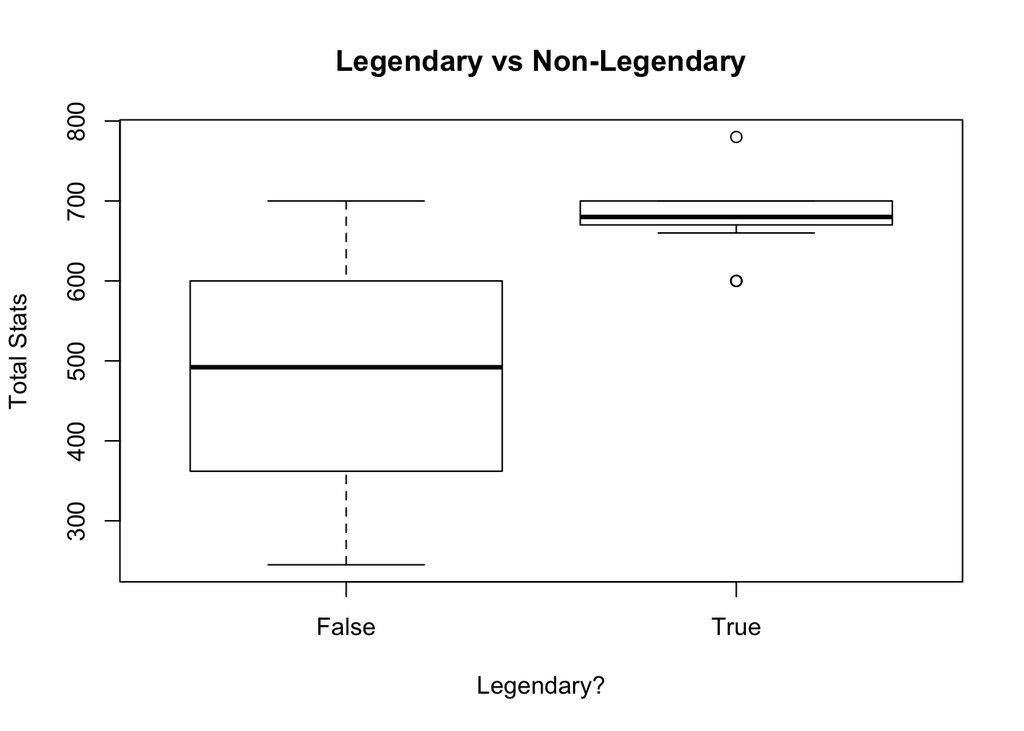

```r
b_plot <- boxplot(Total~Legendary,data=DragonStats, main="Legendary vs Non-Legendary", xlab="Legendary?", ylab="Total Stats")
```

```r
b_plot
```

```
## $stats
##      [,1] [,2]
## [1,]  245  660
## [2,]  362  670
## [3,]  492  680
## [4,]  600  700
## [5,]  700  700
## attr(,"class")
##     False
## "integer"
##
## $n
## [1] 34 16
##
## $conf
##          [,1]   [,2]
## [1,] 427.5097 668.15
## [2,] 556.4903 691.85
##
## $out
## [1] 600 600 780 600
##
## $group
## [1] 2 2 2 2
##
## $names
## [1] "False" "True"
```

By observing this boxplot it is obvious that in general legendary dragon pokemons are stronger than non legendary pokemons almost 100% of the legendary dragon pokemons are stronger than 75% of the non legendary dragon pokemons. ## Hypothesis Testing and Machine Learning For more information on how to do hypothesis testing you can visit this link: http://www.r-tutor.com/elementary-statistics/hypothesis-testing

So from the boxplot it’s very apparent that legendary dragon pokemons are stronger, so I want to do a hypothesis test on whether or not being legendary has a significant impact. The null hypothesis is that there is no significant difference between Legendary Dragon Pokemons and Non-Legendary Dragon Pokemons.  
You can get more information on the broom library by going here: https://cran.r-project.org/web/packages/broom/vignettes/broom.html

```r
lgm <- lm(Total~Legendary, data=DragonStats)
broom::tidy(lgm)
```

```
##            term estimate std.error statistic      p.value
## 1   (Intercept) 479.0588  18.95470 25.273884 2.190136e-29
## 2 LegendaryTrue 195.9412  33.50749  5.847683 4.280380e-07
```

I used a linear regression line to check if being a legendary dragon pokemon has a significant impact on the total stats. Then I used the tidy function from the broom library to create a table. From observing the p.value of the tidied table, I will have to reject the null hypothesis that there is no significant difference between the total stats of Legendary Dragon Pokemons and Non-Legendary Dragon Pokemons because the p.value is 4.280380e-07 which is less than the significance value of 0.05.

Okay, now that we can conclude that legendary dragon pokemons are stronger, let’s do something a bit harder. For example, maybe you want to be a dragon generation pokemon enthusiast who wants to use pokemons of only one generations. We can accomplish this by grouping by the generations. We are going to make three data sets one for the legendaries, one for the non-legendaries and one for both so we can have a comparison.

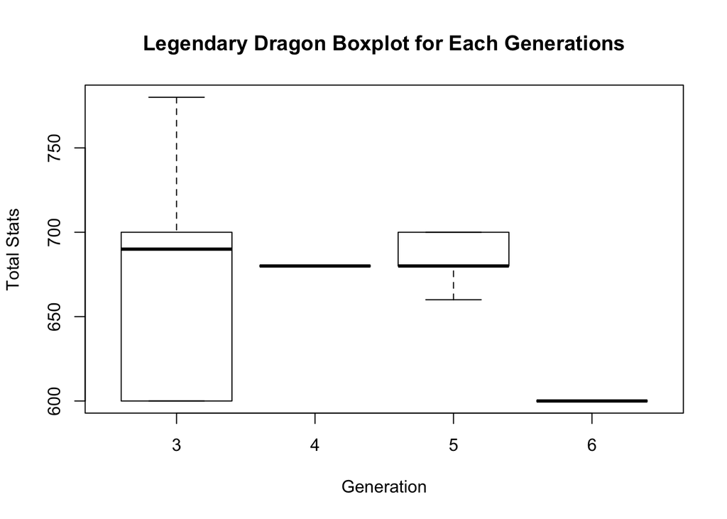

```r
#legendary generation boxplot
l_gen <- boxplot(Total~Generation,data=LegendaryDragons, main="Legendary Dragon Boxplot for Each Generations",xlab="Generation", ylab="Total Stats")
```

```r
l_gen
```

```
## $stats
##      [,1] [,2] [,3] [,4]
## [1,]  600  680  660  600
## [2,]  600  680  680  600
## [3,]  690  680  680  600
## [4,]  700  680  700  600
## [5,]  780  680  700  600
## attr(,"class")
##         3
## "integer"
##
## $n
## [1] 6 4 5 1
##
## $conf
##          [,1] [,2]     [,3] [,4]
## [1,] 625.4968  680 665.8681  600
## [2,] 754.5032  680 694.1319  600
##
## $out
## numeric(0)
##
## $group
## numeric(0)
##
## $names
## [1] "3" "4" "5" "6"
```

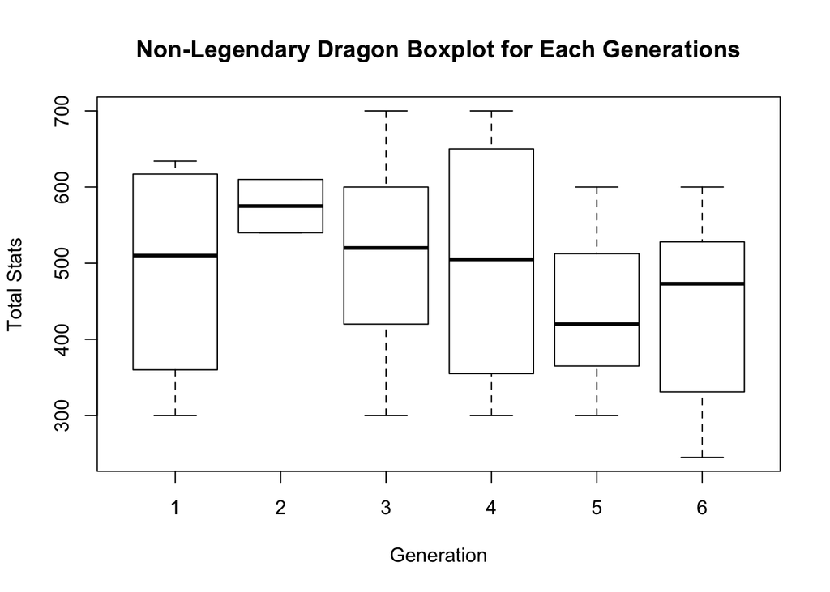

```r
#non-legendary generation boxplot
nl_gen <- boxplot(Total~Generation,data=NonLegendary, main="Non-Legendary Dragon Boxplot for Each Generations",xlab="Generation", ylab="Total Stats")
```

```r
nl_gen
```

```
## $stats
##      [,1] [,2] [,3] [,4]  [,5] [,6]
## [1,]  300  540  300  300 300.0  245
## [2,]  360  540  420  355 365.0  331
## [3,]  510  575  520  505 420.0  473
## [4,]  617  610  600  650 512.5  528
## [5,]  634  610  700  700 600.0  600
## attr(,"class")
##         1
## "integer"
##
## $n
## [1] 4 2 9 4 7 8
##
## $conf
##        [,1]    [,2]  [,3]   [,4]     [,5]    [,6]
## [1,] 306.97 496.794 425.2 271.95 331.9154 362.953
## [2,] 713.03 653.206 614.8 738.05 508.0846 583.047
##
## $out
## numeric(0)
##
## $group
## numeric(0)
##
## $names
## [1] "1" "2" "3" "4" "5" "6"
```

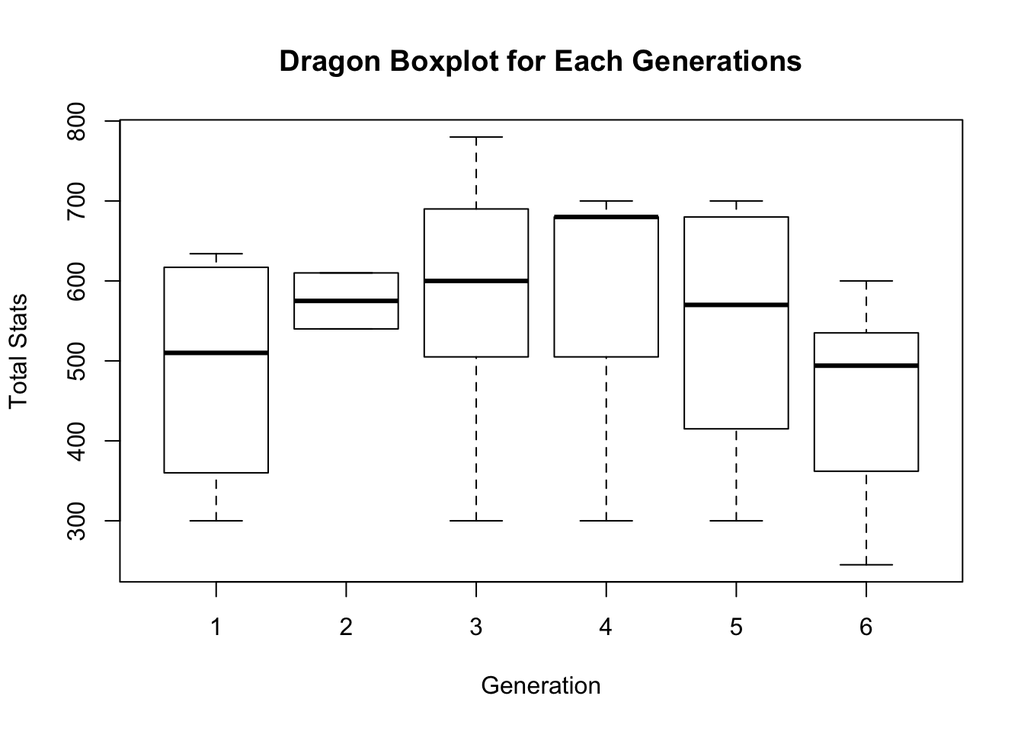

```r
#all dragon generation boxplot
all_gen <- boxplot(Total~Generation,data=DragonStats, main="Dragon Boxplot for Each Generations",xlab="Generation", ylab="Total Stats")
```

```r
all_gen
```

```
## $stats
##      [,1] [,2] [,3] [,4] [,5] [,6]
## [1,]  300  540  300  300  300  245
## [2,]  360  540  505  505  415  362
## [3,]  510  575  600  680  570  494
## [4,]  617  610  690  680  680  535
## [5,]  634  610  780  700  700  600
## attr(,"class")
##         1
## "integer"
##
## $n
## [1]  4  2 15  8 12  9
##
## $conf
##        [,1]    [,2]     [,3]     [,4]     [,5]     [,6]
## [1,] 306.97 496.794 524.5285 582.2425 449.1317 402.8867
## [2,] 713.03 653.206 675.4715 777.7575 690.8683 585.1133
##
## $out
## numeric(0)
##
## $group
## numeric(0)
##
## $names
## [1] "1" "2" "3" "4" "5" "6"
```

What I found interesting here is that there were no legendary dragon pokemons before the 3rd generation, this cause me to be curious about whether or not the generations have a big impact on the total stats. In order to test this I will create a scatter plot and create a regression line on it to see if there is any relationship between generation and total stats.

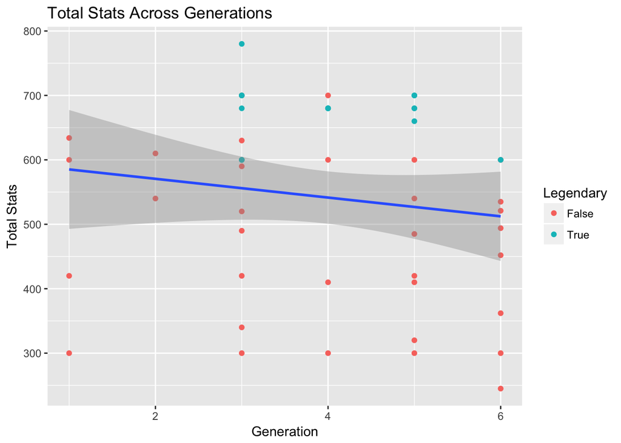

```r
nonvslegend <- DragonStats %>%
  ggplot(mapping = aes(x=Generation,y=Total)) +
  geom_point(aes(color = Legendary)) +
  geom_smooth(method = lm) +
  ggtitle("Total Stats Across Generations") +
  ylab("Total Stats") + xlab("Generation")
nonvslegend
```

```r
lgm <- lm(Total~Generation, data=DragonStats)
broom::tidy(lgm)
```

```
##          term  estimate std.error statistic      p.value
## 1 (Intercept) 599.69434  58.61982 10.230231 1.195849e-13
## 2  Generation -14.55637  13.82451 -1.052939 2.976406e-01
```

This regression line is suprising, it actually shows a slightly negative relationship between generations and total stats. As the generations increases the total stats of dragon type pokemon decreases. I was expecting it to increase. I will now clean up the data a bit more to see if the relationship remains the same.

```r
cleaned <- DragonStats %>%
  group_by(Generation) %>%
  summarize(min_stat=min(Total), mean_stat=mean(Total), max_stat=max(Total) , sd_stat = sd(Total))
cleaned
```

```
## # A tibble: 6 x 5
##   Generation min_stat mean_stat max_stat sd_stat
##        <int>    <dbl>     <dbl>    <dbl>   <dbl>
## 1          1      300       488      634   157
## 2          2      540       575      610    49.5
## 3          3      300       577      780   139
## 4          4      300       591      700   152
## 5          5      300       541      700   150
## 6          6      245       457      600   128
```

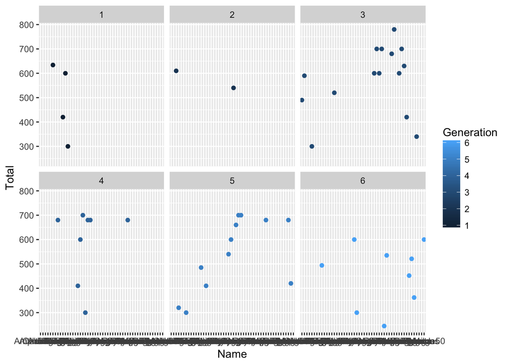

```r
Generation_plot <- ggplot(DragonStats, aes(x = Name, y = Total, colour = Generation)) + geom_point() +
  facet_wrap( ~ Generation)

Generation_plot
```

From the tables and the plots above it suggests that a linear regression model may not be appropriate for this data. So what I will do now is check the residual plots to see how well the linear regression model fits the data.

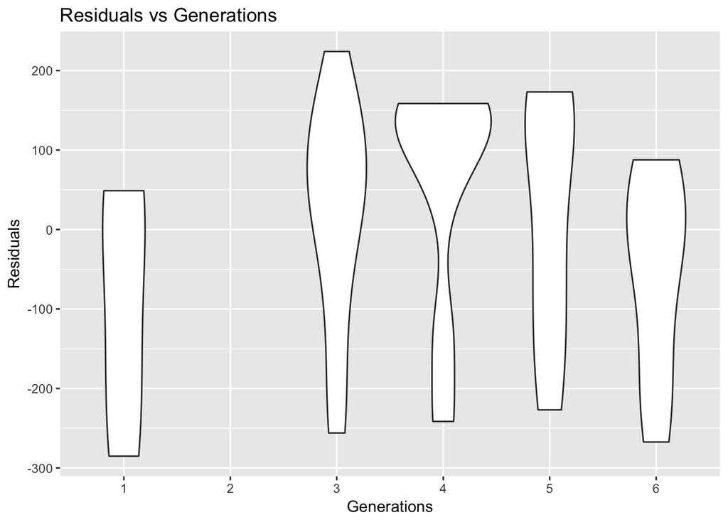

```r
lgm %>%
  broom::augment() %>%
  ggplot(aes(x=factor(Generation), y=.resid)) +
    geom_violin() +
    labs(title="Residuals vs Generations",
         x = "Generations",
         y = "Residuals")
```

From observing the residual violins we can tell that the residuals are not zero centered and the distributions are all weird, some are unimodal some are bimodal and some are neither.